# Cross-cut Summary: sg_focus × FS Bundle (ACTG175 Binary, m1)

This article compares operating characteristics across the cross-product of **`sg_focus`** and **FS parameter bundle** for a fixed study × outcome × DGM × objective combination:

Each cell of the grid corresponds to one bundle file produced by its companion runner script. The full intended grid is declared below; missing bundles are skipped with a message (set `strict_bundles <- TRUE` in setup to error instead).

**Setup, configs, and library loads (click to expand)**

```r
library(forestsearch)
library(data.table)
```

**Setup, configs, and library loads (click to expand)**

```r
library(gt)


# -- Source exploratory utilities ------------------------------------------
# These plotting utilities live outside the forestsearch package (under
# quarto/_utils/) and are sourced directly.  Adjust the relative depth
# if this document is moved within the quarto/ tree.
util_dir <- "../../../../_utils"
source(file.path(util_dir, "plot_oc_metrics.R"))
source(file.path(util_dir, "plot_oc_metrics_3d.R"))
source(file.path(util_dir, "compute_oc_score.R"))
source(file.path(util_dir, "compute_oc_pareto_flag.R"))
source(file.path(util_dir, "compute_oc_score_grid.R"))
source(file.path(util_dir, "consensus_top_k.R"))


# -- Fixed axes (must match every bundle's config) --------------------------
fixed_study     <- "actg175"
fixed_outcome   <- "binary"
fixed_dgm       <- "m1"
fixed_objective <- "harm"
fixed_n         <- 700L     # per-replicate sample size  -> "n{N}"     slot
fixed_sims      <- 1000L    # number of simulation reps  -> "sims{NS}" slot


# bundle_dir <- "../"
# list.files(bundle_dir, pattern = "\\.rds$")
# prefix <- sprintf("^%s_%s_%s_%s_.*\\.rds$",
#                   fixed_study, fixed_outcome, fixed_dgm, fixed_objective)
# list.files(bundle_dir, pattern = prefix, full.names = TRUE)
# #
# [10] "..//actg175_binary_m1_harm_fs2_eff_neighborhood_n700_sims1000.rds"
# [11] "..//actg175_binary_m1_harm_fs2_effMaxSG_both_n700_sims1000.rds"
# [12] "..//actg175_binary_m1_harm_fs2_effMaxSG_neighborhood_n700_sims1000.rds"
# [13] "..//actg175_binary_m1_harm_fs2_effMaxSG_pareto_n700_sims1000.rds"
# [14] "..//actg175_binary_m1_harm_fs2_effMinSG_both_n700_sims1000.rds"
# [15] "..//actg175_binary_m1_harm_fs2_effMinSG_neighborhood_n700_sims1000.rds"
# [16] "..//actg175_binary_m1_harm_fs2_effMinSG_pareto_n700_sims1000.rds"
# [17] "..//actg175_binary_m1_harm_fs2_maxSG_neighborhood_n700_sims1000.rds"
# [18] "..//actg175_binary_m1_harm_fs2_minSG_neighborhood_n700_sims1000.rds"


# → only actg175_binary_m1_harm_* bundles, full paths
# Base R adds %||% in 4.4; define a fallback for older R.
if (!exists("%||%", mode = "function")) {
  `%||%` <- function(x, y) if (is.null(x)) y else x
}

# -- Levels to compare ------------------------------------------------------
# Edit these vectors as bundles become available.  expand.grid() builds
# the full cross-product; missing bundles are skipped (or error if
# strict_bundles = TRUE).
# Note: fs7 is same as fs3 except use_twostage = FALSE
# They are generally same

focus_levels   <- c("eff_neighborhood",
                    "maxSG_neighborhood","effMaxSG_neighborhood","effMaxSG_pareto","effMaxSG_both",
                    "minSG_neighborhood","effMinSG_neighborhood","effMinSG_pareto","effMinSG_both"
                    )
fs_levels      <- c("fs1","fs2","fs3","fs4","fs5","fs6")
strict_bundles <- FALSE

# -- Build configs ----------------------------------------------------------
# Path is relative to this qmd's directory
# (i.e., quarto/simulations/actg175/_summaries/).
configs <- expand.grid(
  focus = focus_levels,
  fs    = fs_levels,
  KEEP.OUT.ATTRS   = FALSE,
  stringsAsFactors = FALSE
)
# Sort by focus first, then fs (matches the naming convention).
configs <- configs[order(
  match(configs$focus, focus_levels),
  match(configs$fs,    fs_levels)
), , drop = FALSE]
rownames(configs) <- NULL
configs$config_id <- sprintf(
  "%s_%s_%s_%s_%s_%s_n%d_sims%d",
  fixed_study, fixed_outcome, fixed_dgm, fixed_objective, configs$fs,
  configs$focus,
  fixed_n, fixed_sims
)
configs$label       <- sprintf("%s × %s", configs$focus, configs$fs)
configs$bundle_path <- sprintf("../%s.rds", configs$config_id)

# -- Filter to existing bundles --------------------------------------------
exists_flag <- vapply(configs$bundle_path, file.exists, logical(1))
if (!all(exists_flag)) {
  miss_msg <- sprintf("Missing %d of %d bundles:\n  %s",
                      sum(!exists_flag), nrow(configs),
                      paste(configs$config_id[!exists_flag],
                            collapse = "\n  "))
  if (strict_bundles) {
    stop(miss_msg, call. = FALSE)
  } else {
    message(miss_msg)
    configs <- configs[exists_flag, , drop = FALSE]
  }
}

if (nrow(configs) == 0L) {
  stop("No bundles available to compare. Build at least one bundle first.",
       call. = FALSE)
}

# -- Display options --------------------------------------------------------
sg_notation <- "harm"

# -- Conditional trimming for OR estimates ---------------------------------
# When the |mean - median| / |median| ratio exceeds or_trim_threshold for
# a given OR estimate (computed across replicates with detection), the
# raw mean is being pulled by extreme values. In that case we report a
# trimmed mean instead. Cells where the rule does not trigger keep the
# raw mean (preserving the standard "on average" interpretation).
#
# Set or_trim_threshold = Inf to disable conditional trimming entirely.
or_trim_threshold <- 0.20    # 20% gap between mean and median triggers trim
or_trim           <- 0.05    # 5% trimmed mean from each tail when triggered

cat(sprintf("Comparing %d configuration(s):\n", nrow(configs)))
```

```
Comparing 54 configuration(s):
```

**Setup, configs, and library loads (click to expand)**

```r
print(configs[, c("label", "config_id")])
```

```
                         label
1       eff_neighborhood × fs1
2       eff_neighborhood × fs2
3       eff_neighborhood × fs3
4       eff_neighborhood × fs4
5       eff_neighborhood × fs5
6       eff_neighborhood × fs6
7     maxSG_neighborhood × fs1
8     maxSG_neighborhood × fs2
9     maxSG_neighborhood × fs3
10    maxSG_neighborhood × fs4
11    maxSG_neighborhood × fs5
12    maxSG_neighborhood × fs6
13 effMaxSG_neighborhood × fs1
14 effMaxSG_neighborhood × fs2
```

[output cut: 95 more lines]

# Load bundles

**Bundle loading + validation (click to expand)**

```r
bundles <- setNames(lapply(configs$bundle_path, readRDS), configs$label)

# Soft-validate config_id matches what's declared in `configs`
for (i in seq_len(nrow(configs))) {
  meta_id <- bundles[[i]]$meta$config_id
  if (!is.null(meta_id) && meta_id != configs$config_id[i]) {
    warning(sprintf(
      "Bundle '%s' has config_id '%s' but configs declares '%s'.",
      configs$label[i], meta_id, configs$config_id[i]
    ), call. = FALSE)
  }
}
```

## Bundle metadata

**Per-bundle metadata table (click to expand)**

```r
meta_dt <- data.table::rbindlist(lapply(seq_along(bundles), function(i) {
  m <- bundles[[i]]$meta
  data.frame(
    label           = configs$label[i],
    focus           = configs$focus[i],
    fs              = configs$fs[i],
    timestamp       = format(m$timestamp     %||% NA),
    n_alt           = m$n_alt                %||% NA_integer_,
    n_null          = m$n_null               %||% NA_integer_,
    sim_n           = m$sim_n                %||% NA_integer_,
    n_failed_alt    = m$n_failed_alt         %||% NA_integer_,
    n_failed_null   = m$n_failed_null        %||% NA_integer_,
    t_alt_min       = round((m$t_alt_sec  %||% NA) / 60, 1),
    t_null_min      = round((m$t_null_sec %||% NA) / 60, 1),
    package_version = m$package_version      %||% NA_character_,
    stringsAsFactors = FALSE
  )
}))

gt::gt(meta_dt) |>
  gt::tab_header(title = "Bundle metadata") |>
  gt::sub_missing(missing_text = "—")
```

Bundle metadata

| label | focus | fs | timestamp | n_alt | n_null | sim_n | n_failed_alt | n_failed_null | t_alt_min | t_null_min | package_version |
| --- | --- | --- | --- | --- | --- | --- | --- | --- | --- | --- | --- |
| eff_neighborhood × fs1 | eff_neighborhood | fs1 | 2026-05-15 14:13:54 | 1000 | 1000 | 700 | 0 | 0 | 10.1 | 10.2 | 0.2.0 |
| eff_neighborhood × fs2 | eff_neighborhood | fs2 | 2026-05-15 10:28:23 | 1000 | 1000 | 700 | 0 | 0 | 5.8 | 5.4 | 0.2.0 |
| eff_neighborhood × fs3 | eff_neighborhood | fs3 | 2026-05-17 17:30:39 | 1000 | 1000 | 700 | 0 | 0 | 7.1 | 7.0 | 0.2.0 |
| eff_neighborhood × fs4 | eff_neighborhood | fs4 | 2026-05-17 11:17:52 | 1000 | 1000 | 700 | 0 | 0 | 6.7 | 6.2 | 0.2.0 |
| eff_neighborhood × fs5 | eff_neighborhood | fs5 | 2026-05-17 14:08:43 | 1000 | 1000 | 700 | 0 | 0 | 13.7 | 14.7 | 0.2.0 |
| eff_neighborhood × fs6 | eff_neighborhood | fs6 | 2026-05-17 23:08:08 | 1000 | 1000 | 700 | 0 | 0 | 8.9 | 8.7 | 0.2.0 |
| maxSG_neighborhood × fs1 | maxSG_neighborhood | fs1 | 2026-05-15 17:22:11 | 1000 | 1000 | 700 | 0 | 0 | 11.7 | 10.3 | 0.2.0 |
| maxSG_neighborhood × fs2 | maxSG_neighborhood | fs2 | 2026-05-15 12:46:54 | 1000 | 1000 | 700 | 0 | 0 | 7.2 | 5.7 | 0.2.0 |
| maxSG_neighborhood × fs3 | maxSG_neighborhood | fs3 | 2026-05-17 20:54:20 | 1000 | 1000 | 700 | 0 | 0 | 10.7 | 8.6 | 0.2.0 |
| maxSG_neighborhood × fs4 | maxSG_neighborhood | fs4 | 2026-05-17 14:38:12 | 1000 | 1000 | 700 | 0 | 0 | 7.7 | 6.6 | 0.2.0 |
| maxSG_neighborhood × fs5 | maxSG_neighborhood | fs5 | 2026-05-17 20:29:26 | 1000 | 1000 | 700 | 0 | 0 | 22.4 | 18.9 | 0.2.0 |
| maxSG_neighborhood × fs6 | maxSG_neighborhood | fs6 | 2026-05-18 03:09:38 | 1000 | 1000 | 700 | 0 | 0 | 9.9 | 9.2 | 0.2.0 |
| effMaxSG_neighborhood × fs1 | effMaxSG_neighborhood | fs1 | 2026-05-15 15:09:48 | 1000 | 1000 | 700 | 0 | 0 | 12.4 | 11.7 | 0.2.0 |
| effMaxSG_neighborhood × fs2 | effMaxSG_neighborhood | fs2 | 2026-05-15 11:08:45 | 1000 | 1000 | 700 | 0 | 0 | 8.7 | 6.5 | 0.2.0 |
| effMaxSG_neighborhood × fs3 | effMaxSG_neighborhood | fs3 | 2026-05-17 18:30:41 | 1000 | 1000 | 700 | 0 | 0 | 13.2 | 10.1 | 0.2.0 |
| effMaxSG_neighborhood × fs4 | effMaxSG_neighborhood | fs4 | 2026-05-17 12:16:58 | 1000 | 1000 | 700 | 0 | 0 | 13.3 | 9.6 | 0.2.0 |
| effMaxSG_neighborhood × fs5 | effMaxSG_neighborhood | fs5 | 2026-05-17 16:07:54 | 1000 | 1000 | 700 | 0 | 0 | 27.8 | 20.5 | 0.2.0 |
| effMaxSG_neighborhood × fs6 | effMaxSG_neighborhood | fs6 | 2026-05-18 00:20:08 | 1000 | 1000 | 700 | 0 | 0 | 17.0 | 12.1 | 0.2.0 |
| effMaxSG_pareto × fs1 | effMaxSG_pareto | fs1 | 2026-05-15 15:38:01 | 1000 | 1000 | 700 | 0 | 0 | 12.7 | 11.3 | 0.2.0 |
| effMaxSG_pareto × fs2 | effMaxSG_pareto | fs2 | 2026-05-15 11:28:55 | 1000 | 1000 | 700 | 0 | 0 | 8.5 | 6.6 | 0.2.0 |
| effMaxSG_pareto × fs3 | effMaxSG_pareto | fs3 | 2026-05-17 19:00:22 | 1000 | 1000 | 700 | 0 | 0 | 12.6 | 10.0 | 0.2.0 |
| effMaxSG_pareto × fs4 | effMaxSG_pareto | fs4 | 2026-05-17 12:46:36 | 1000 | 1000 | 700 | 0 | 0 | 13.4 | 9.5 | 0.2.0 |
| effMaxSG_pareto × fs5 | effMaxSG_pareto | fs5 | 2026-05-17 17:07:58 | 1000 | 1000 | 700 | 0 | 0 | 27.9 | 20.8 | 0.2.0 |
| effMaxSG_pareto × fs6 | effMaxSG_pareto | fs6 | 2026-05-18 00:55:55 | 1000 | 1000 | 700 | 0 | 0 | 17.0 | 12.2 | 0.2.0 |
| effMaxSG_both × fs1 | effMaxSG_both | fs1 | 2026-05-15 14:41:38 | 1000 | 1000 | 700 | 0 | 0 | 12.5 | 11.2 | 0.2.0 |
| effMaxSG_both × fs2 | effMaxSG_both | fs2 | 2026-05-15 10:48:25 | 1000 | 1000 | 700 | 0 | 0 | 8.5 | 6.3 | 0.2.0 |
| effMaxSG_both × fs3 | effMaxSG_both | fs3 | 2026-05-17 18:00:20 | 1000 | 1000 | 700 | 0 | 0 | 12.7 | 9.7 | 0.2.0 |
| effMaxSG_both × fs4 | effMaxSG_both | fs4 | 2026-05-17 11:47:33 | 1000 | 1000 | 700 | 0 | 0 | 13.5 | 9.5 | 0.2.0 |
| effMaxSG_both × fs5 | effMaxSG_both | fs5 | 2026-05-17 15:08:56 | 1000 | 1000 | 700 | 0 | 0 | 27.9 | 20.8 | 0.2.0 |
| effMaxSG_both × fs6 | effMaxSG_both | fs6 | 2026-05-17 23:44:26 | 1000 | 1000 | 700 | 0 | 0 | 17.5 | 12.3 | 0.2.0 |
| minSG_neighborhood × fs1 | minSG_neighborhood | fs1 | 2026-05-15 17:42:52 | 1000 | 1000 | 700 | 0 | 0 | 10.2 | 10.2 | 0.2.0 |
| minSG_neighborhood × fs2 | minSG_neighborhood | fs2 | 2026-05-15 13:03:13 | 1000 | 1000 | 700 | 0 | 0 | 6.4 | 5.6 | 0.2.0 |
| minSG_neighborhood × fs3 | minSG_neighborhood | fs3 | 2026-05-17 21:15:27 | 1000 | 1000 | 700 | 0 | 0 | 8.8 | 7.8 | 0.2.0 |
| minSG_neighborhood × fs4 | minSG_neighborhood | fs4 | 2026-05-17 14:57:25 | 1000 | 1000 | 700 | 0 | 0 | 8.1 | 6.9 | 0.2.0 |
| minSG_neighborhood × fs5 | minSG_neighborhood | fs5 | 2026-05-17 21:05:15 | 1000 | 1000 | 700 | 0 | 0 | 15.9 | 16.0 | 0.2.0 |
| minSG_neighborhood × fs6 | minSG_neighborhood | fs6 | 2026-05-18 03:32:30 | 1000 | 1000 | 700 | 0 | 0 | 10.7 | 9.5 | 0.2.0 |
| effMinSG_neighborhood × fs1 | effMinSG_neighborhood | fs1 | 2026-05-15 16:32:48 | 1000 | 1000 | 700 | 0 | 0 | 12.2 | 11.6 | 0.2.0 |
| effMinSG_neighborhood × fs2 | effMinSG_neighborhood | fs2 | 2026-05-15 12:08:57 | 1000 | 1000 | 700 | 0 | 0 | 8.7 | 6.4 | 0.2.0 |
| effMinSG_neighborhood × fs3 | effMinSG_neighborhood | fs3 | 2026-05-17 19:59:44 | 1000 | 1000 | 700 | 0 | 0 | 13.0 | 10.3 | 0.2.0 |
| effMinSG_neighborhood × fs4 | effMinSG_neighborhood | fs4 | 2026-05-17 13:48:12 | 1000 | 1000 | 700 | 0 | 0 | 13.9 | 9.6 | 0.2.0 |
| effMinSG_neighborhood × fs5 | effMinSG_neighborhood | fs5 | 2026-05-17 18:50:19 | 1000 | 1000 | 700 | 0 | 0 | 24.4 | 19.2 | 0.2.0 |
| effMinSG_neighborhood × fs6 | effMinSG_neighborhood | fs6 | 2026-05-18 02:10:29 | 1000 | 1000 | 700 | 0 | 0 | 17.9 | 12.1 | 0.2.0 |
| effMinSG_pareto × fs1 | effMinSG_pareto | fs1 | 2026-05-15 16:59:58 | 1000 | 1000 | 700 | 0 | 0 | 12.2 | 11.4 | 0.2.0 |
| effMinSG_pareto × fs2 | effMinSG_pareto | fs2 | 2026-05-15 12:28:59 | 1000 | 1000 | 700 | 0 | 0 | 8.6 | 6.5 | 0.2.0 |
| effMinSG_pareto × fs3 | effMinSG_pareto | fs3 | 2026-05-17 20:29:20 | 1000 | 1000 | 700 | 0 | 0 | 12.9 | 9.9 | 0.2.0 |
| effMinSG_pareto × fs4 | effMinSG_pareto | fs4 | 2026-05-17 14:19:19 | 1000 | 1000 | 700 | 0 | 0 | 14.2 | 9.8 | 0.2.0 |
| effMinSG_pareto × fs5 | effMinSG_pareto | fs5 | 2026-05-17 19:41:34 | 1000 | 1000 | 700 | 0 | 0 | 24.4 | 19.2 | 0.2.0 |
| effMinSG_pareto × fs6 | effMinSG_pareto | fs6 | 2026-05-18 02:48:00 | 1000 | 1000 | 700 | 0 | 0 | 18.2 | 12.2 | 0.2.0 |
| effMinSG_both × fs1 | effMinSG_both | fs1 | 2026-05-15 16:05:37 | 1000 | 1000 | 700 | 0 | 0 | 12.2 | 11.8 | 0.2.0 |
| effMinSG_both × fs2 | effMinSG_both | fs2 | 2026-05-15 11:48:56 | 1000 | 1000 | 700 | 0 | 0 | 8.7 | 6.4 | 0.2.0 |
| effMinSG_both × fs3 | effMinSG_both | fs3 | 2026-05-19 06:27:47 | 1000 | 1000 | 700 | 0 | 0 | 26.6 | 11.3 | 0.2.0 |
| effMinSG_both × fs4 | effMinSG_both | fs4 | 2026-05-17 13:17:46 | 1000 | 1000 | 700 | 0 | 0 | 14.3 | 9.8 | 0.2.0 |
| effMinSG_both × fs5 | effMinSG_both | fs5 | 2026-05-17 17:59:00 | 1000 | 1000 | 700 | 0 | 0 | 24.1 | 19.2 | 0.2.0 |
| effMinSG_both × fs6 | effMinSG_both | fs6 | 2026-05-18 01:33:15 | 1000 | 1000 | 700 | 0 | 0 | 18.1 | 12.1 | 0.2.0 |

# Unified H1 Operating Characteristics

A single combined table with one row per (config × analysis method). FS rows are grouped by `sg_focus × fs` so detection, classification, and effect estimates can be compared across `sg_focus` criteria.

GRF does not depend on `sg_focus` (its results are invariant across the focus criteria), so a single GRF row is shown at the end of the table under its own group rather than redundantly within each focus group.

The DGM truth (target OR, true subgroup, prevalence) is fixed across all configurations and shown once in the table subtitle, rather than repeated per cell.

**Compute per-(config × analysis) H1 OC metrics (click to expand)**

```r
# DGM truth values are fixed across configs (all share m1).
# Use the first available bundle's calibrated DGM as the reference.
ref_dgm <- bundles[[1]]$dgm$calibrated
or_target_H  <- ref_dgm$hazard_ratios$harm_subgroup
or_target_Hc <- ref_dgm$hazard_ratios$no_harm_subgroup
or_target_ITT <- ref_dgm$hazard_ratios$overall

# -- Helper: conditional trimmed mean ----------------------------------------
# Returns a list with the chosen mean (raw or trimmed) and a flag
# indicating whether trimming was applied. The rule is the mean-vs-median
# ratio: if |mean - median| / |median| exceeds the threshold, the mean
# is being pulled by extreme values and we report a trimmed mean.
# Otherwise the raw mean is returned (preserving "on average" reading).
cond_trim_mean <- function(x,
                           threshold = or_trim_threshold,
                           trim      = or_trim,
                           na.rm     = TRUE) {
  x_clean <- if (na.rm) x[!is.na(x)] else x
  if (length(x_clean) == 0L) {
    return(list(value = NA_real_, trimmed = FALSE))
  }
  mu  <- mean(x_clean)
  med <- stats::median(x_clean)
  # Avoid division by zero / sign issues; require a meaningful median
  if (is.na(med) || med == 0 || !is.finite(med)) {
    return(list(value = mu, trimmed = FALSE))
  }
  if (abs(mu - med) / abs(med) > threshold) {
    list(value = mean(x_clean, trim = trim), trimmed = TRUE)
  } else {
    list(value = mu, trimmed = FALSE)
  }
}

# Compute the same summary statistics format_oc_results() does, but
# combined across all configurations into one long data.frame.
oc_rows <- data.table::rbindlist(lapply(seq_len(nrow(configs)), function(i) {
  b <- bundles[[i]]
  res <- b$results$alt
  if (is.null(res) || nrow(res) == 0L) return(NULL)
  dt <- data.table::as.data.table(res)

  per_analysis <- lapply(unique(dt$analysis), function(a) {
    r       <- dt[analysis == a]
    r_found <- r[any.H == 1L]
    n_sims  <- length(unique(r$sim))

    # Conditional trimming applied to the three OR estimates
    or_h_hat   <- if (nrow(r_found)) cond_trim_mean(r_found$hr.H.hat)  else list(value = NA_real_, trimmed = FALSE)
    or_hc_hat  <- if (nrow(r_found)) cond_trim_mean(r_found$hr.Hc.hat) else list(value = NA_real_, trimmed = FALSE)
    or_itt     <- cond_trim_mean(r$hr.itt)

    list(
      group              = sprintf("%s × %s", configs$focus[i], configs$fs[i]),
      Analysis           = a,
      N_sims             = n_sims,
      Detection          = mean(r$any.H == 1L, na.rm = TRUE),
      Sen                = mean(r$sens, na.rm = TRUE),
      Spec               = mean(r$spec, na.rm = TRUE),
      PPV                = mean(r$ppv, na.rm = TRUE),
      NPV                = mean(r$npv, na.rm = TRUE),
      OR_H_hat           = or_h_hat$value,
      OR_H_trimmed       = or_h_hat$trimmed,
      OR_Hc_hat          = or_hc_hat$value,
      OR_Hc_trimmed      = or_hc_hat$trimmed,
      OR_ITT             = or_itt$value,
      OR_ITT_trimmed     = or_itt$trimmed,
      Size_H_mean        = if (nrow(r_found)) mean(r_found$size.H, na.rm = TRUE) else NA_real_,
      Size_H_min         = if (nrow(r_found)) min(r_found$size.H,  na.rm = TRUE) else NA_integer_,
      Size_H_max         = if (nrow(r_found)) max(r_found$size.H,  na.rm = TRUE) else NA_integer_
    )
  })
  data.table::rbindlist(per_analysis)
}))

# Replace NaN (from mean of all-NA) with NA for clean display.
# Skip logical columns (the *_trimmed flags).
for (col in names(oc_rows)) {
  if (is.numeric(oc_rows[[col]])) {
    oc_rows[is.nan(get(col)), (col) := NA]
  }
}

# Combined trim-flag column for compact display
oc_rows[, Trim := {
  flags <- character(.N)
  for (i in seq_len(.N)) {
    parts <- character(0)
    if (isTRUE(OR_H_trimmed[i]))   parts <- c(parts, "H")
    if (isTRUE(OR_Hc_trimmed[i]))  parts <- c(parts, "Hᶜ")
    if (isTRUE(OR_ITT_trimmed[i])) parts <- c(parts, "ITT")
    flags[i] <- if (length(parts)) paste(parts, collapse = ",") else ""
  }
  flags
}]

# Order: by configs row order (focus × fs), then analysis (FS, GRF)
oc_rows[, group := factor(group,
                          levels = sprintf("%s × %s",
                                           configs$focus, configs$fs))]
data.table::setorder(oc_rows, group, Analysis)

# -- Collapse redundant GRF rows -----------------------------------------
# GRF does not depend on sg_focus, so its results are identical across
# the focus groups. We collapse the redundant rows into a single GRF
# row at the end of the table, displayed under its own group.
#
# Sanity check: warn if GRF metrics actually differ across focus groups,
# which would suggest a bundle inconsistency rather than a true GRF
# invariance.
grf_rows <- oc_rows[Analysis == "GRF"]
if (nrow(grf_rows) > 1L) {
  metric_cols <- c("Detection", "Sen", "Spec", "PPV", "NPV",
                   "OR_H_hat", "OR_Hc_hat", "OR_ITT",
                   "Size_H_mean", "Size_H_min", "Size_H_max")
  # Check (within tolerance for floating point)
  inconsistent <- vapply(metric_cols, function(col) {
    vals <- grf_rows[[col]]
    vals <- vals[!is.na(vals)]
    if (length(vals) <= 1L) return(FALSE)
    diff_range <- max(vals) - min(vals)
    # Tolerance: 1e-8 absolute or 1e-6 relative to median
    abs_med <- abs(stats::median(vals))
    diff_range > max(1e-8, 1e-6 * abs_med)
  }, logical(1))
  if (any(inconsistent)) {
    warning(sprintf(
      "GRF rows differ across focus groups in column(s): %s. Collapsing anyway using the first focus group's values; investigate if unexpected.",
      paste(names(which(inconsistent)), collapse = ", ")
    ), call. = FALSE)
  }
}

# Keep one GRF row (relabel its group), drop the rest, append at end
if (nrow(grf_rows) > 0L) {
  one_grf <- grf_rows[1L]
  one_grf[, group := "GRF (sg_focus-invariant)"]
  oc_rows <- rbind(
    oc_rows[Analysis != "GRF"],
    one_grf
  )
  # Re-establish factor levels so the GRF group sorts to the end
  fs_grp_levels <- sprintf("%s × %s", configs$focus, configs$fs)
  oc_rows[, group := factor(group,
                            levels = c(fs_grp_levels,
                                       "GRF (sg_focus-invariant)"))]
  data.table::setorder(oc_rows, group, Analysis)
}

# How many cells got trimmed (used to decide whether to expose Trim col)
n_trimmed_cells <- sum(oc_rows$Trim != "")
```

```r
# Build subtitle: include trim rule wording only if any cells got trimmed.
oc_subtitle <- sprintf(
  "Truth (m1): OR(Q) = %.2f, OR(Qc) = %.2f, OR(ITT) = %.2f — same across all configs",
  or_target_H, or_target_Hc, or_target_ITT
)
if (n_trimmed_cells > 0L) {
  oc_subtitle <- paste0(
    oc_subtitle,
    sprintf(
      ". OR estimates are raw means; cells where |mean − median|/|median| > %.0f%% report a %.0f%% trimmed mean instead (flagged in Trim column).",
      100 * or_trim_threshold, 100 * or_trim
    )
  )
}

# Drop the per-OR boolean trim flags from display; the combined Trim
# column is the user-facing flag.
display_dt <- oc_rows[, !c("OR_H_trimmed", "OR_Hc_trimmed", "OR_ITT_trimmed")]

# If no cell needed trimming, drop the Trim column too (no signal to surface)
if (n_trimmed_cells == 0L) {
  display_dt[, Trim := NULL]
}

g <- display_dt |>
  gt::gt(groupname_col = "group") |>
  gt::tab_header(
    title    = "H1 Operating Characteristics — focus × fs comparison",
    subtitle = oc_subtitle
  ) |>
  gt::cols_label(
    Analysis    = "Analysis",
    N_sims      = "N",
    Detection   = "Detect",
    Sen         = "Sen",
    Spec        = "Spec",
    PPV         = "PPV",
    NPV         = "NPV",
    OR_H_hat    = "ÔR(Ĥ)",
    OR_Hc_hat   = "ÔR(Ĥᶜ)",
    OR_ITT      = "ÔR(ITT)",
    Size_H_mean = "|Ĥ| mean",
    Size_H_min  = "min",
    Size_H_max  = "max"
  ) |>
  gt::tab_spanner(label = "Detection / Classification",
                  columns = c(Detection, Sen, Spec, PPV, NPV)) |>
  gt::tab_spanner(label = "Effect estimates",
                  columns = c(OR_H_hat, OR_Hc_hat, OR_ITT)) |>
  gt::tab_spanner(label = "Subgroup size |Ĥ|",
                  columns = c(Size_H_mean, Size_H_min, Size_H_max)) |>
  gt::fmt_number(columns = c(Detection, Sen, Spec, PPV, NPV), decimals = 3) |>
  gt::fmt_number(columns = c(OR_H_hat, OR_Hc_hat, OR_ITT), decimals = 2) |>
  gt::fmt_number(columns = Size_H_mean, decimals = 1) |>
  gt::fmt_number(columns = c(Size_H_min, Size_H_max), decimals = 0) |>
  gt::sub_missing(missing_text = "—")

if (n_trimmed_cells > 0L) {
  g <- g |> gt::cols_label(Trim = "Trim")
}

g
```

H1 Operating Characteristics — focus × fs comparison

Truth (m1): OR(Q) = 2.00, OR(Qc) = 0.66, OR(ITT) = 0.75 — same across all configs

| Analysis | N | Detection / Classification Detect | Detection / Classification Sen | Detection / Classification Spec | Detection / Classification PPV | Detection / Classification NPV | Effect estimates ÔR(Ĥ) | Effect estimates ÔR(Ĥᶜ) | Effect estimates ÔR(ITT) | Subgroup size \|Ĥ\| \|Ĥ\| mean | Subgroup size \|Ĥ\| min | Subgroup size \|Ĥ\| max |
| --- | --- | --- | --- | --- | --- | --- | --- | --- | --- | --- | --- | --- |
| eff_neighborhood × fs1 |  |  |  |  |  |  |  |  |  |  |  |  |
| FS | 1000 | 0.904 | 0.438 | 0.924 | 0.439 | 0.941 | 3.56 | 0.64 | 0.75 | 83.0 | 61 | 358 |
| eff_neighborhood × fs2 |  |  |  |  |  |  |  |  |  |  |  |  |
| FS | 1000 | 0.913 | 0.431 | 0.924 | 0.434 | 0.939 | 3.57 | 0.64 | 0.75 | 82.2 | 61 | 313 |
| eff_neighborhood × fs3 |  |  |  |  |  |  |  |  |  |  |  |  |
| FS | 1000 | 0.920 | 0.433 | 0.926 | 0.440 | 0.939 | 3.63 | 0.64 | 0.75 | 81.0 | 61 | 313 |
| eff_neighborhood × fs4 |  |  |  |  |  |  |  |  |  |  |  |  |
| FS | 1000 | 0.911 | 0.465 | 0.875 | 0.315 | 0.941 | 2.53 | 0.61 | 0.75 | 118.8 | 101 | 313 |
| eff_neighborhood × fs5 |  |  |  |  |  |  |  |  |  |  |  |  |
| FS | 1000 | 0.911 | 0.463 | 0.874 | 0.314 | 0.940 | 2.53 | 0.61 | 0.75 | 119.0 | 101 | 313 |
| eff_neighborhood × fs6 |  |  |  |  |  |  |  |  |  |  |  |  |
| FS | 1000 | 0.888 | 0.435 | 0.865 | 0.281 | 0.939 | 2.45 | 0.61 | 0.75 | 124.3 | 101 | 313 |
| maxSG_neighborhood × fs1 |  |  |  |  |  |  |  |  |  |  |  |  |
| FS | 1000 | 0.308 | 0.204 | 0.827 | 0.072 | 0.983 | 1.67 | 0.53 | 0.75 | 247.0 | 75 | 571 |
| maxSG_neighborhood × fs2 |  |  |  |  |  |  |  |  |  |  |  |  |
| FS | 1000 | 0.507 | 0.312 | 0.801 | 0.119 | 0.969 | 1.73 | 0.53 | 0.75 | 226.5 | 64 | 618 |
| maxSG_neighborhood × fs3 |  |  |  |  |  |  |  |  |  |  |  |  |
| FS | 1000 | 0.801 | 0.481 | 0.775 | 0.204 | 0.951 | 1.78 | 0.55 | 0.75 | 204.3 | 61 | 618 |
| maxSG_neighborhood × fs4 |  |  |  |  |  |  |  |  |  |  |  |  |
| FS | 1000 | 0.911 | 0.543 | 0.754 | 0.214 | 0.943 | 1.61 | 0.56 | 0.75 | 208.2 | 101 | 502 |
| maxSG_neighborhood × fs5 |  |  |  |  |  |  |  |  |  |  |  |  |
| FS | 1000 | 0.908 | 0.567 | 0.706 | 0.199 | 0.943 | 1.50 | 0.54 | 0.75 | 243.0 | 101 | 647 |
| maxSG_neighborhood × fs6 |  |  |  |  |  |  |  |  |  |  |  |  |
| FS | 1000 | 0.888 | 0.519 | 0.765 | 0.213 | 0.943 | 1.63 | 0.57 | 0.75 | 201.4 | 101 | 508 |
| effMaxSG_neighborhood × fs1 |  |  |  |  |  |  |  |  |  |  |  |  |
| FS | 1000 | 0.907 | 0.442 | 0.918 | 0.422 | 0.941 | 3.51 | 0.63 | 0.75 | 87.4 | 61 | 358 |
| effMaxSG_neighborhood × fs2 |  |  |  |  |  |  |  |  |  |  |  |  |
| FS | 1000 | 0.912 | 0.435 | 0.918 | 0.417 | 0.940 | 3.52 | 0.63 | 0.75 | 86.4 | 61 | 313 |
| effMaxSG_neighborhood × fs3 |  |  |  |  |  |  |  |  |  |  |  |  |
| FS | 1000 | 0.918 | 0.445 | 0.922 | 0.433 | 0.940 | 3.59 | 0.63 | 0.75 | 84.6 | 61 | 241 |

[output cut: 80 more lines]

**Augment display_dt with Pareto-frontier flag and composite score (click to expand)**

```r
# Pareto frontier on {Detection, Sen, Spec}, all higher-is-better.
# PPV and NPV remain in display_dt as descriptive columns alongside,
# available for use as plot aesthetics or for inclusion in summary
# tables but not contributing to dominance evaluation.
display_dt <- compute_oc_pareto_flag(
  display_dt,
  metrics  = c("Detection", "Sen", "Spec"),
  flag_col = "pareto_frontier"
)

# Composite scalar score -- linear-weighted convex combination of the
# same three metrics.  Auto-normalised weights.  Default weights here
# are (1.5, 1, 1.75): the "benefit-protection" weighting, which gives
# Spec the largest weight.  Rationale: in the harm-subgroup framing
# of forestsearch, high Spec on the harm class corresponds to low
# false-positive harm calls -- equivalently, high Sen for the
# complementary benefit recommendation Hc.  Weighting Spec above Sen
# therefore reflects the operational goal of capturing as many true
# beneficiaries as possible in the treatment recommendation.  See
# the "Robustness across weightings" section below for a sensitivity
# analysis across alternative weight choices.
display_dt <- compute_oc_score(
  display_dt,
  method    = "linear",
  metrics   = c("Detection", "Sen", "Spec"),
  weights   = c(1.5, 1, 1.75),
  score_col = "S"
)

n_frontier <- sum(display_dt$pareto_frontier, na.rm = TRUE)
cat(sprintf(
  "Pareto frontier: %d of %d configurations are non-dominated on {Detection, Sen, Spec}.\n",
  n_frontier, nrow(display_dt)
))
```

```
Pareto frontier: 22 of 55 configurations are non-dominated on {Detection, Sen, Spec}.
```

## Graphical views

The unified OC table presents many metrics for many configurations in a dense form. The plots below are complementary low-resolution views: each maps three or four of the same columns onto a single visual so that cross-configuration patterns are easier to scan. Both views use the `display_dt` table built above, so any change in the trimming rule or in the focus / fs grid flows through here automatically. The plotting code lives in `quarto/_utils/plot_oc_metrics.R` and `quarto/_utils/plot_oc_metrics_3d.R` and is intentionally outside the forestsearch package.

### 2D bubble: Spec × NPV × Detection (defaults)

**2D bubble: Spec × NPV with Detection as bubble size**

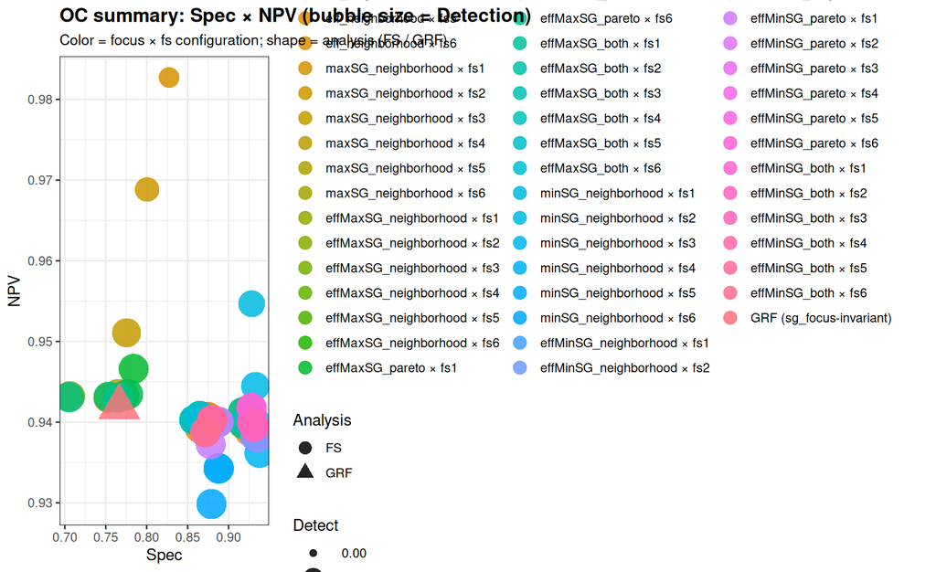

```r
plot_oc_metrics(
  display_dt,
  size_limits = c(0, 1),
  title       = "OC summary: Spec × NPV (bubble size = Detection)",
  subtitle    = "Color = focus × fs configuration; shape = analysis (FS / GRF)"
)
```

### 2D bubble: alternative axes (effect-size view)

**2D bubble: Sen × PPV with ÔR(Ĥ) as bubble size**

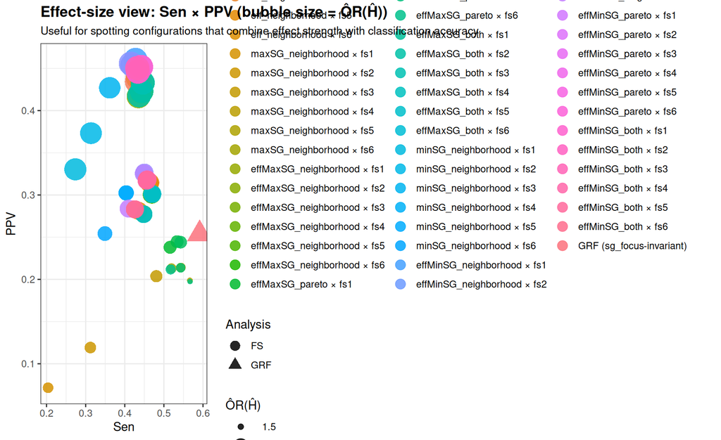

```r
plot_oc_metrics(
  display_dt,
  x        = "Sen",
  y        = "PPV",
  z        = "OR_H_hat",
  title    = "Effect-size view: Sen × PPV (bubble size = ÔR(Ĥ))",
  subtitle = "Useful for spotting configurations that combine effect strength with classification accuracy"
)
```

### Pareto frontier overlay

A configuration is **on the Pareto frontier** when no other configuration matches it on every one of {Detection, Sen, Spec} and strictly beats it on at least one. Frontier configurations represent defensible operating points: any non-frontier configuration is dominated by at least one frontier configuration simultaneously on all three axes. PPV and NPV are not part of the dominance evaluation but are shown alongside in the frontier table below as descriptive columns.

The bubble plot below uses the same axes as the default view but highlights frontier points (full opacity, thicker stroke) and dims dominated points (reduced opacity).

**2D bubble with Pareto-frontier highlighting**

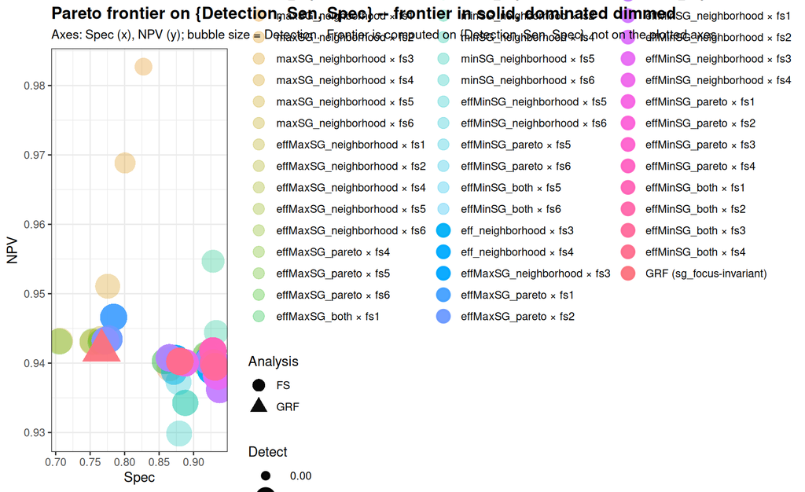

```r
plot_oc_metrics(
  display_dt,
  pareto_col  = "pareto_frontier",
  size_limits = c(0, 1),
  title       = "Pareto frontier on {Detection, Sen, Spec} -- frontier in solid, dominated dimmed",
  subtitle    = "Axes: Spec (x), NPV (y); bubble size = Detection.  Frontier is computed on {Detection, Sen, Spec}, not on the plotted axes."
)
```

The table below lists the frontier configurations with all five classification metrics shown. PPV and NPV appear here as descriptive columns – they did not influence frontier membership but help characterise each defensible operating point.

**Frontier configurations with descriptive PPV/NPV alongside**

```r
frontier_cols <- c("group", "Analysis", "N_sims",
                   "Detection", "Sen", "Spec", "PPV", "NPV", "S")
frontier_dt <- display_dt[
  display_dt$pareto_frontier %in% TRUE,
  ..frontier_cols
]
data.table::setorder(frontier_dt, -S)

gt::gt(frontier_dt) |>
  gt::tab_header(
    title    = "Pareto-frontier configurations",
    subtitle = "Frontier defined on {Detection, Sen, Spec} (bold).  PPV, NPV, S shown alongside as descriptive columns; rows sorted by S descending."
  ) |>
  gt::tab_spanner(label = "Frontier metrics",
                  columns = c(Detection, Sen, Spec)) |>
  gt::tab_spanner(label = "Descriptive",
                  columns = c(PPV, NPV, S)) |>
  gt::cols_label(
    Analysis  = "Analysis",
    N_sims    = "N",
    Detection = "Detect",
    Sen       = "Sen",
    Spec      = "Spec",
    PPV       = "PPV",
    NPV       = "NPV",
    S         = "S (linear; w = 1.5, 1, 1.75)"
  ) |>
  gt::fmt_number(columns = c(Detection, Sen, Spec, PPV, NPV, S), decimals = 3) |>
  gt::sub_missing(missing_text = "—")
```

Pareto-frontier configurations

Frontier defined on {Detection, Sen, Spec} (bold). PPV, NPV, S shown alongside as descriptive columns; rows sorted by S descending.

| group | Analysis | N | Frontier metrics Detect | Frontier metrics Sen | Frontier metrics Spec | Descriptive PPV | Descriptive NPV | Descriptive S (linear; w = 1.5, 1, 1.75) |
| --- | --- | --- | --- | --- | --- | --- | --- | --- |
| effMaxSG_both × fs3 | FS | 1000 | 0.920 | 0.446 | 0.922 | 0.433 | 0.940 | 0.809 |
| effMinSG_pareto × fs3 | FS | 1000 | 0.918 | 0.432 | 0.931 | 0.450 | 0.939 | 0.809 |
| effMinSG_both × fs3 | FS | 1000 | 0.918 | 0.432 | 0.931 | 0.450 | 0.939 | 0.809 |
| effMaxSG_neighborhood × fs3 | FS | 1000 | 0.918 | 0.445 | 0.922 | 0.433 | 0.940 | 0.808 |
| eff_neighborhood × fs3 | FS | 1000 | 0.920 | 0.433 | 0.926 | 0.440 | 0.939 | 0.808 |
| effMinSG_pareto × fs2 | FS | 1000 | 0.915 | 0.434 | 0.929 | 0.446 | 0.940 | 0.807 |
| effMinSG_both × fs2 | FS | 1000 | 0.915 | 0.434 | 0.929 | 0.446 | 0.940 | 0.807 |
| effMinSG_pareto × fs1 | FS | 1000 | 0.908 | 0.442 | 0.928 | 0.452 | 0.942 | 0.807 |
| effMinSG_both × fs1 | FS | 1000 | 0.908 | 0.442 | 0.928 | 0.452 | 0.942 | 0.807 |
| effMinSG_neighborhood × fs2 | FS | 1000 | 0.917 | 0.419 | 0.933 | 0.454 | 0.938 | 0.807 |
| effMinSG_neighborhood × fs1 | FS | 1000 | 0.910 | 0.428 | 0.933 | 0.460 | 0.940 | 0.806 |
| effMinSG_neighborhood × fs3 | FS | 1000 | 0.915 | 0.415 | 0.935 | 0.456 | 0.938 | 0.806 |
| GRF (sg_focus-invariant) | GRF | 1000 | 0.985 | 0.591 | 0.767 | 0.254 | 0.942 | 0.802 |
| effMinSG_neighborhood × fs4 | FS | 1000 | 0.911 | 0.450 | 0.888 | 0.326 | 0.940 | 0.793 |
| effMinSG_pareto × fs4 | FS | 1000 | 0.911 | 0.457 | 0.880 | 0.318 | 0.940 | 0.792 |
| effMinSG_both × fs4 | FS | 1000 | 0.911 | 0.457 | 0.880 | 0.318 | 0.940 | 0.792 |
| eff_neighborhood × fs4 | FS | 1000 | 0.911 | 0.465 | 0.875 | 0.315 | 0.941 | 0.791 |
| effMaxSG_both × fs4 | FS | 1000 | 0.910 | 0.470 | 0.865 | 0.301 | 0.941 | 0.788 |
| minSG_neighborhood × fs3 | FS | 1000 | 0.883 | 0.362 | 0.938 | 0.427 | 0.936 | 0.783 |
| effMaxSG_pareto × fs3 | FS | 1000 | 0.921 | 0.543 | 0.772 | 0.244 | 0.943 | 0.771 |
| effMaxSG_pareto × fs2 | FS | 1000 | 0.913 | 0.534 | 0.777 | 0.245 | 0.943 | 0.768 |
| effMaxSG_pareto × fs1 | FS | 1000 | 0.875 | 0.516 | 0.784 | 0.238 | 0.947 | 0.753 |

#### Robustness across weightings

The single composite score above uses the benefit-protection weighting `(1.5, 1, 1.75)` – a deliberate but ultimately subjective choice. The chunks below repeat the scoring under four alternative weightings (equal, Spec-emphasis, Detection-emphasis, Sen-emphasis) and identify the configurations that rank in the top-K under **every** weighting. These are the configurations whose preference is robust to the weighting choice; a configuration whose rank swings sharply across weightings is an artefact of the weights rather than a defensible operating point.

**Compute scores across the default weight grid + consensus top-K**

```r
# Augment with one score column per weighting in the default grid.
# Adds S_equal, S_bp_default, S_spec_emphasis, S_detect_emphasis, S_sen_emphasis.
display_dt <- compute_oc_score_grid(display_dt)

# Identify configurations top-5 under EVERY weighting.
score_cols_grid <- paste0("S_", c("equal", "bp_default", "spec_emphasis",
                                  "detect_emphasis", "sen_emphasis"))
display_dt <- consensus_top_k(
  display_dt,
  score_cols = score_cols_grid,
  k          = 5L,
  flag_col   = "consensus_top5"
)

cat(sprintf(
  "Consensus top-5: %d configuration(s) rank in the top-5 under all %d weightings.\n",
  sum(display_dt$consensus_top5, na.rm = TRUE),
  length(score_cols_grid)
))
```

```
Consensus top-5: 0 configuration(s) rank in the top-5 under all 5 weightings.
```

**Compute scores across the default weight grid + consensus top-K**

```r
cat(sprintf(
  "Pareto frontier AND consensus top-5: %d configuration(s).\n",
  sum(display_dt$pareto_frontier & display_dt$consensus_top5, na.rm = TRUE)
))
```

```
Pareto frontier AND consensus top-5: 0 configuration(s).
```

The table below shows the consensus top-5 configurations (top-5 under all five weightings) with one score column per weighting, ordered by the benefit-protection score. The `Pareto` column indicates whether the configuration also lies on the Pareto frontier of {Detection, Sen, Spec} – configurations that pass both filters are robustly preferred *and* not dominated on any single classification axis.

**Consensus top-5 configurations with all grid scores**

```r
consensus_cols <- c("group", "Analysis",
                    "Detection", "Sen", "Spec",
                    "pareto_frontier",
                    "S_equal", "S_bp_default", "S_spec_emphasis",
                    "S_detect_emphasis", "S_sen_emphasis")
consensus_dt <- display_dt[
  display_dt$consensus_top5 %in% TRUE,
  ..consensus_cols
]
data.table::setorder(consensus_dt, -S_bp_default)

# Rename the logical flag for nicer display
data.table::setnames(consensus_dt, "pareto_frontier", "Pareto")

gt::gt(consensus_dt) |>
  gt::tab_header(
    title    = "Consensus top-5 across all five weightings",
    subtitle = "Configurations top-5 under {equal, bp_default, spec_emphasis, detect_emphasis, sen_emphasis}.  'Pareto' flags also-on-frontier on {Detection, Sen, Spec}."
  ) |>
  gt::tab_spanner(label = "Classification metrics",
                  columns = c(Detection, Sen, Spec)) |>
  gt::tab_spanner(label = "Scores by weighting",
                  columns = c(S_equal, S_bp_default, S_spec_emphasis,
                              S_detect_emphasis, S_sen_emphasis)) |>
  gt::cols_label(
    Analysis          = "Analysis",
    Detection         = "Detect",
    Sen               = "Sen",
    Spec              = "Spec",
    Pareto            = "Pareto",
    S_equal           = "equal",
    S_bp_default      = "bp_default",
    S_spec_emphasis   = "spec_emph",
    S_detect_emphasis = "detect_emph",
    S_sen_emphasis    = "sen_emph"
  ) |>
  gt::fmt_number(columns = c(Detection, Sen, Spec),
                 decimals = 3) |>
  gt::fmt_number(columns = c(S_equal, S_bp_default, S_spec_emphasis,
                              S_detect_emphasis, S_sen_emphasis),
                 decimals = 3) |>
  gt::sub_missing(missing_text = "—")
```

Consensus top-5 across all five weightings

Configurations top-5 under {equal, bp_default, spec_emphasis, detect_emphasis, sen_emphasis}. 'Pareto' flags also-on-frontier on {Detection, Sen, Spec}.

| group | Analysis | Classification metrics | Classification metrics | Classification metrics | Pareto | Scores by weighting | Scores by weighting | Scores by weighting | Scores by weighting | Scores by weighting |
| --- | --- | --- | --- | --- | --- | --- | --- | --- | --- | --- |
|  |  | Detect | Sen | Spec |  | equal | bp_default | spec_emph | detect_emph | sen_emph |

The default weight grid is defined in `compute_oc_score_grid.R` (see `.OC_WEIGHT_GRID_DEFAULT`); pass a custom `weight_grid` argument to explore a different set of weightings. Adjust the top-K cutoff via the `k` argument of `consensus_top_k()` for a stricter (e.g. `k = 3`) or looser (e.g. `k = 8`) consensus.

### 3D interactive view (rotate to disambiguate depth)

The plot below is an HTML widget rendered by plotly; rotation, zoom, and per-point hover are all interactive. Static screenshots of 3D scatter plots are routinely misleading because perspective alone does not resolve depth, so the intended use is to rotate the view in the rendered HTML. This chunk does not produce output in PDF; for PDF reports, use the 2D bubble views above.

**3D scatter: Spec × NPV × Detection (interactive)**

```r
plot_oc_metrics_3d(
  display_dt,
  title = "OC summary: Spec × NPV × Detection (rotate to read depth)"
)
```

[interactive chart not shown]

# Per-config Detail

For deep-dives into any single configuration, see the corresponding per-config article.

Per-config articles and bundles

| Config | Per-config article | Bundle (.rds) |
| --- | --- | --- |
| eff_neighborhood × fs1 | ../actg175_binary_m1_harm_fs1_eff_neighborhood_n700_sims1000.qmd | ../actg175_binary_m1_harm_fs1_eff_neighborhood_n700_sims1000.rds |
| eff_neighborhood × fs2 | ../actg175_binary_m1_harm_fs2_eff_neighborhood_n700_sims1000.qmd | ../actg175_binary_m1_harm_fs2_eff_neighborhood_n700_sims1000.rds |
| eff_neighborhood × fs3 | ../actg175_binary_m1_harm_fs3_eff_neighborhood_n700_sims1000.qmd | ../actg175_binary_m1_harm_fs3_eff_neighborhood_n700_sims1000.rds |
| eff_neighborhood × fs4 | ../actg175_binary_m1_harm_fs4_eff_neighborhood_n700_sims1000.qmd | ../actg175_binary_m1_harm_fs4_eff_neighborhood_n700_sims1000.rds |
| eff_neighborhood × fs5 | ../actg175_binary_m1_harm_fs5_eff_neighborhood_n700_sims1000.qmd | ../actg175_binary_m1_harm_fs5_eff_neighborhood_n700_sims1000.rds |
| eff_neighborhood × fs6 | ../actg175_binary_m1_harm_fs6_eff_neighborhood_n700_sims1000.qmd | ../actg175_binary_m1_harm_fs6_eff_neighborhood_n700_sims1000.rds |
| maxSG_neighborhood × fs1 | ../actg175_binary_m1_harm_fs1_maxSG_neighborhood_n700_sims1000.qmd | ../actg175_binary_m1_harm_fs1_maxSG_neighborhood_n700_sims1000.rds |
| maxSG_neighborhood × fs2 | ../actg175_binary_m1_harm_fs2_maxSG_neighborhood_n700_sims1000.qmd | ../actg175_binary_m1_harm_fs2_maxSG_neighborhood_n700_sims1000.rds |
| maxSG_neighborhood × fs3 | ../actg175_binary_m1_harm_fs3_maxSG_neighborhood_n700_sims1000.qmd | ../actg175_binary_m1_harm_fs3_maxSG_neighborhood_n700_sims1000.rds |
| maxSG_neighborhood × fs4 | ../actg175_binary_m1_harm_fs4_maxSG_neighborhood_n700_sims1000.qmd | ../actg175_binary_m1_harm_fs4_maxSG_neighborhood_n700_sims1000.rds |
| maxSG_neighborhood × fs5 | ../actg175_binary_m1_harm_fs5_maxSG_neighborhood_n700_sims1000.qmd | ../actg175_binary_m1_harm_fs5_maxSG_neighborhood_n700_sims1000.rds |
| maxSG_neighborhood × fs6 | ../actg175_binary_m1_harm_fs6_maxSG_neighborhood_n700_sims1000.qmd | ../actg175_binary_m1_harm_fs6_maxSG_neighborhood_n700_sims1000.rds |
| effMaxSG_neighborhood × fs1 | ../actg175_binary_m1_harm_fs1_effMaxSG_neighborhood_n700_sims1000.qmd | ../actg175_binary_m1_harm_fs1_effMaxSG_neighborhood_n700_sims1000.rds |
| effMaxSG_neighborhood × fs2 | ../actg175_binary_m1_harm_fs2_effMaxSG_neighborhood_n700_sims1000.qmd | ../actg175_binary_m1_harm_fs2_effMaxSG_neighborhood_n700_sims1000.rds |
| effMaxSG_neighborhood × fs3 | ../actg175_binary_m1_harm_fs3_effMaxSG_neighborhood_n700_sims1000.qmd | ../actg175_binary_m1_harm_fs3_effMaxSG_neighborhood_n700_sims1000.rds |
| effMaxSG_neighborhood × fs4 | ../actg175_binary_m1_harm_fs4_effMaxSG_neighborhood_n700_sims1000.qmd | ../actg175_binary_m1_harm_fs4_effMaxSG_neighborhood_n700_sims1000.rds |
| effMaxSG_neighborhood × fs5 | ../actg175_binary_m1_harm_fs5_effMaxSG_neighborhood_n700_sims1000.qmd | ../actg175_binary_m1_harm_fs5_effMaxSG_neighborhood_n700_sims1000.rds |
| effMaxSG_neighborhood × fs6 | ../actg175_binary_m1_harm_fs6_effMaxSG_neighborhood_n700_sims1000.qmd | ../actg175_binary_m1_harm_fs6_effMaxSG_neighborhood_n700_sims1000.rds |
| effMaxSG_pareto × fs1 | ../actg175_binary_m1_harm_fs1_effMaxSG_pareto_n700_sims1000.qmd | ../actg175_binary_m1_harm_fs1_effMaxSG_pareto_n700_sims1000.rds |
| effMaxSG_pareto × fs2 | ../actg175_binary_m1_harm_fs2_effMaxSG_pareto_n700_sims1000.qmd | ../actg175_binary_m1_harm_fs2_effMaxSG_pareto_n700_sims1000.rds |
| effMaxSG_pareto × fs3 | ../actg175_binary_m1_harm_fs3_effMaxSG_pareto_n700_sims1000.qmd | ../actg175_binary_m1_harm_fs3_effMaxSG_pareto_n700_sims1000.rds |
| effMaxSG_pareto × fs4 | ../actg175_binary_m1_harm_fs4_effMaxSG_pareto_n700_sims1000.qmd | ../actg175_binary_m1_harm_fs4_effMaxSG_pareto_n700_sims1000.rds |
| effMaxSG_pareto × fs5 | ../actg175_binary_m1_harm_fs5_effMaxSG_pareto_n700_sims1000.qmd | ../actg175_binary_m1_harm_fs5_effMaxSG_pareto_n700_sims1000.rds |
| effMaxSG_pareto × fs6 | ../actg175_binary_m1_harm_fs6_effMaxSG_pareto_n700_sims1000.qmd | ../actg175_binary_m1_harm_fs6_effMaxSG_pareto_n700_sims1000.rds |
| effMaxSG_both × fs1 | ../actg175_binary_m1_harm_fs1_effMaxSG_both_n700_sims1000.qmd | ../actg175_binary_m1_harm_fs1_effMaxSG_both_n700_sims1000.rds |
| effMaxSG_both × fs2 | ../actg175_binary_m1_harm_fs2_effMaxSG_both_n700_sims1000.qmd | ../actg175_binary_m1_harm_fs2_effMaxSG_both_n700_sims1000.rds |
| effMaxSG_both × fs3 | ../actg175_binary_m1_harm_fs3_effMaxSG_both_n700_sims1000.qmd | ../actg175_binary_m1_harm_fs3_effMaxSG_both_n700_sims1000.rds |
| effMaxSG_both × fs4 | ../actg175_binary_m1_harm_fs4_effMaxSG_both_n700_sims1000.qmd | ../actg175_binary_m1_harm_fs4_effMaxSG_both_n700_sims1000.rds |
| effMaxSG_both × fs5 | ../actg175_binary_m1_harm_fs5_effMaxSG_both_n700_sims1000.qmd | ../actg175_binary_m1_harm_fs5_effMaxSG_both_n700_sims1000.rds |
| effMaxSG_both × fs6 | ../actg175_binary_m1_harm_fs6_effMaxSG_both_n700_sims1000.qmd | ../actg175_binary_m1_harm_fs6_effMaxSG_both_n700_sims1000.rds |
| minSG_neighborhood × fs1 | ../actg175_binary_m1_harm_fs1_minSG_neighborhood_n700_sims1000.qmd | ../actg175_binary_m1_harm_fs1_minSG_neighborhood_n700_sims1000.rds |
| minSG_neighborhood × fs2 | ../actg175_binary_m1_harm_fs2_minSG_neighborhood_n700_sims1000.qmd | ../actg175_binary_m1_harm_fs2_minSG_neighborhood_n700_sims1000.rds |
| minSG_neighborhood × fs3 | ../actg175_binary_m1_harm_fs3_minSG_neighborhood_n700_sims1000.qmd | ../actg175_binary_m1_harm_fs3_minSG_neighborhood_n700_sims1000.rds |
| minSG_neighborhood × fs4 | ../actg175_binary_m1_harm_fs4_minSG_neighborhood_n700_sims1000.qmd | ../actg175_binary_m1_harm_fs4_minSG_neighborhood_n700_sims1000.rds |
| minSG_neighborhood × fs5 | ../actg175_binary_m1_harm_fs5_minSG_neighborhood_n700_sims1000.qmd | ../actg175_binary_m1_harm_fs5_minSG_neighborhood_n700_sims1000.rds |
| minSG_neighborhood × fs6 | ../actg175_binary_m1_harm_fs6_minSG_neighborhood_n700_sims1000.qmd | ../actg175_binary_m1_harm_fs6_minSG_neighborhood_n700_sims1000.rds |
| effMinSG_neighborhood × fs1 | ../actg175_binary_m1_harm_fs1_effMinSG_neighborhood_n700_sims1000.qmd | ../actg175_binary_m1_harm_fs1_effMinSG_neighborhood_n700_sims1000.rds |
| effMinSG_neighborhood × fs2 | ../actg175_binary_m1_harm_fs2_effMinSG_neighborhood_n700_sims1000.qmd | ../actg175_binary_m1_harm_fs2_effMinSG_neighborhood_n700_sims1000.rds |
| effMinSG_neighborhood × fs3 | ../actg175_binary_m1_harm_fs3_effMinSG_neighborhood_n700_sims1000.qmd | ../actg175_binary_m1_harm_fs3_effMinSG_neighborhood_n700_sims1000.rds |
| effMinSG_neighborhood × fs4 | ../actg175_binary_m1_harm_fs4_effMinSG_neighborhood_n700_sims1000.qmd | ../actg175_binary_m1_harm_fs4_effMinSG_neighborhood_n700_sims1000.rds |
| effMinSG_neighborhood × fs5 | ../actg175_binary_m1_harm_fs5_effMinSG_neighborhood_n700_sims1000.qmd | ../actg175_binary_m1_harm_fs5_effMinSG_neighborhood_n700_sims1000.rds |
| effMinSG_neighborhood × fs6 | ../actg175_binary_m1_harm_fs6_effMinSG_neighborhood_n700_sims1000.qmd | ../actg175_binary_m1_harm_fs6_effMinSG_neighborhood_n700_sims1000.rds |
| effMinSG_pareto × fs1 | ../actg175_binary_m1_harm_fs1_effMinSG_pareto_n700_sims1000.qmd | ../actg175_binary_m1_harm_fs1_effMinSG_pareto_n700_sims1000.rds |
| effMinSG_pareto × fs2 | ../actg175_binary_m1_harm_fs2_effMinSG_pareto_n700_sims1000.qmd | ../actg175_binary_m1_harm_fs2_effMinSG_pareto_n700_sims1000.rds |
| effMinSG_pareto × fs3 | ../actg175_binary_m1_harm_fs3_effMinSG_pareto_n700_sims1000.qmd | ../actg175_binary_m1_harm_fs3_effMinSG_pareto_n700_sims1000.rds |
| effMinSG_pareto × fs4 | ../actg175_binary_m1_harm_fs4_effMinSG_pareto_n700_sims1000.qmd | ../actg175_binary_m1_harm_fs4_effMinSG_pareto_n700_sims1000.rds |
| effMinSG_pareto × fs5 | ../actg175_binary_m1_harm_fs5_effMinSG_pareto_n700_sims1000.qmd | ../actg175_binary_m1_harm_fs5_effMinSG_pareto_n700_sims1000.rds |
| effMinSG_pareto × fs6 | ../actg175_binary_m1_harm_fs6_effMinSG_pareto_n700_sims1000.qmd | ../actg175_binary_m1_harm_fs6_effMinSG_pareto_n700_sims1000.rds |
| effMinSG_both × fs1 | ../actg175_binary_m1_harm_fs1_effMinSG_both_n700_sims1000.qmd | ../actg175_binary_m1_harm_fs1_effMinSG_both_n700_sims1000.rds |
| effMinSG_both × fs2 | ../actg175_binary_m1_harm_fs2_effMinSG_both_n700_sims1000.qmd | ../actg175_binary_m1_harm_fs2_effMinSG_both_n700_sims1000.rds |
| effMinSG_both × fs3 | ../actg175_binary_m1_harm_fs3_effMinSG_both_n700_sims1000.qmd | ../actg175_binary_m1_harm_fs3_effMinSG_both_n700_sims1000.rds |
| effMinSG_both × fs4 | ../actg175_binary_m1_harm_fs4_effMinSG_both_n700_sims1000.qmd | ../actg175_binary_m1_harm_fs4_effMinSG_both_n700_sims1000.rds |
| effMinSG_both × fs5 | ../actg175_binary_m1_harm_fs5_effMinSG_both_n700_sims1000.qmd | ../actg175_binary_m1_harm_fs5_effMinSG_both_n700_sims1000.rds |
| effMinSG_both × fs6 | ../actg175_binary_m1_harm_fs6_effMinSG_both_n700_sims1000.qmd | ../actg175_binary_m1_harm_fs6_effMinSG_both_n700_sims1000.rds |

# Notes